# ML Assignment: Submitted by Chinar Arora(CXA180005)

```python
import os
from fnmatch import fnmatch
import pandas as pd
import matplotlib.pyplot as plt
import numpy as np
from sklearn.model_selection import train_test_split
from sklearn import preprocessing
import seaborn as sns

import warnings
warnings.filterwarnings('ignore')
```

```python
root = '/Users/chinararora/Documents/Semester_2@UTD/ML/Assignment-1/Dataset/Data'
pattern = "*.csv"
csv_list = []
for path, subdirs, files in os.walk(root):
    for name in files:
        if fnmatch(name, pattern):
            csv_list.append(os.path.join(path, name))
```

```python
csv_out = 'consolidated.csv'
csv_header = 'Page_Popularity,Page_Checkins,Page_talking_about,Page_category,Min_E1,Max_E1,Avg_E1,Median_E1,Std_E1,Min_E2,Max_E2,Avg_E2,Median_E2,Std_E2,Min_E3,Max_E3,Avg_E3,Median_E3,Std_E3,Min_E4,Max_E4,Avg_E4,Median_E4,Std_E4,Min_E5,Max_E5,Avg_E5,Median_E5,Std_E5,CC1,CC2,CC3,CC4,CC5,Base_Time,Post_length,Post_share_count,Post_promotion_status,H_local,Post_Sunday,Post_Monday,Post_Tuesday,Post_Wednesday,Post_Thursday,Post_Friday,Post_Saturday,Base_Sunday,Base_Monday,Base_Tuesday,Base_Wednesday,Base_Thursday,Base_Friday,Base_Saturday,Comments_Next_Hhours'
csv_merge = open(csv_out, 'w')
csv_merge.write(csv_header)
csv_merge.write('\n')

for file in csv_list:

    csv_in = open(file)
    for line in csv_in:
        csv_merge.write(line)
```

```python
df=pd.read_csv(csv_out)
df.head()
```

|  | Page_Popularity | Page_Checkins | Page_talking_about | Page_category | Min_E1 | Max_E1 | Avg_E1 | Median_E1 | Std_E1 | Min_E2 | ... | Post_Friday | Post_Saturday | Base_Sunday | Base_Monday | Base_Tuesday | Base_Wednesday | Base_Thursday | Base_Friday | Base_Saturday | Comments_Next_Hhours |
| --- | --- | --- | --- | --- | --- | --- | --- | --- | --- | --- | --- | --- | --- | --- | --- | --- | --- | --- | --- | --- | --- |
| 0 | 634995 | 0 | 463 | 1 | 0.0 | 1279.0 | 13.214829 | 1.0 | 96.799769 | 0.0 | ... | 0 | 0 | 0 | 0 | 0 | 0 | 0 | 1 | 0 | 0 |
| 1 | 634995 | 0 | 463 | 1 | 0.0 | 1279.0 | 13.214829 | 1.0 | 96.799769 | 0.0 | ... | 0 | 0 | 0 | 0 | 0 | 0 | 0 | 0 | 1 | 0 |
| 2 | 634995 | 0 | 463 | 1 | 0.0 | 1279.0 | 13.214829 | 1.0 | 96.799769 | 0.0 | ... | 1 | 0 | 1 | 0 | 0 | 0 | 0 | 0 | 0 | 0 |
| 3 | 634995 | 0 | 463 | 1 | 0.0 | 1279.0 | 13.214829 | 1.0 | 96.799769 | 0.0 | ... | 1 | 0 | 1 | 0 | 0 | 0 | 0 | 0 | 0 | 0 |
| 4 | 634995 | 0 | 463 | 1 | 0.0 | 1279.0 | 13.214829 | 1.0 | 96.799769 | 0.0 | ... | 0 | 0 | 0 | 0 | 0 | 0 | 1 | 0 | 0 | 0 |

5 rows × 54 columns

```python
df.shape
```

```
(161410, 54)
```

```python
df.columns
```

```
Index(['Page_Popularity', 'Page_Checkins', 'Page_talking_about',
       'Page_category', 'Min_E1', 'Max_E1', 'Avg_E1', 'Median_E1', 'Std_E1',
       'Min_E2', 'Max_E2', 'Avg_E2', 'Median_E2', 'Std_E2', 'Min_E3', 'Max_E3',
       'Avg_E3', 'Median_E3', 'Std_E3', 'Min_E4', 'Max_E4', 'Avg_E4',
       'Median_E4', 'Std_E4', 'Min_E5', 'Max_E5', 'Avg_E5', 'Median_E5',
       'Std_E5', 'CC1', 'CC2', 'CC3', 'CC4', 'CC5', 'Base_Time', 'Post_length',
       'Post_share_count', 'Post_promotion_status', 'H_local', 'Post_Sunday',
       'Post_Monday', 'Post_Tuesday', 'Post_Wednesday', 'Post_Thursday',
       'Post_Friday', 'Post_Saturday', 'Base_Sunday', 'Base_Monday',
       'Base_Tuesday', 'Base_Wednesday', 'Base_Thursday', 'Base_Friday',
       'Base_Saturday', 'Comments_Next_Hhours'],
      dtype='object')
```

```python
#df.info()
```

#### Randomly partitioning dataset using 70/30 split rule

```python
xTrain, xTest, yTrain, yTest = train_test_split(df.iloc[:,0:53],df.iloc[:,-1], test_size = 0.3, random_state = 0)
```

```python
xTrain.head()
```

|  | Page_Popularity | Page_Checkins | Page_talking_about | Page_category | Min_E1 | Max_E1 | Avg_E1 | Median_E1 | Std_E1 | Min_E2 | ... | Post_Thursday | Post_Friday | Post_Saturday | Base_Sunday | Base_Monday | Base_Tuesday | Base_Wednesday | Base_Thursday | Base_Friday | Base_Saturday |
| --- | --- | --- | --- | --- | --- | --- | --- | --- | --- | --- | --- | --- | --- | --- | --- | --- | --- | --- | --- | --- | --- |
| 143059 | 1340759 | 33935 | 49392 | 9 | 0.0 | 591.0 | 58.654066 | 32.0 | 82.057083 | 0.0 | ... | 0 | 1 | 0 | 0 | 0 | 0 | 0 | 0 | 0 | 1 |
| 84923 | 3280313 | 1 | 39324 | 14 | 0.0 | 1609.0 | 195.898477 | 141.5 | 197.891384 | 0.0 | ... | 0 | 1 | 0 | 0 | 1 | 0 | 0 | 0 | 0 | 0 |
| 127752 | 274207 | 0 | 100435 | 18 | 0.0 | 664.0 | 130.589330 | 79.0 | 131.079556 | 0.0 | ... | 1 | 0 | 0 | 0 | 0 | 0 | 0 | 0 | 1 | 0 |
| 52483 | 3159268 | 0 | 155474 | 73 | 0.0 | 127.0 | 17.308756 | 13.0 | 19.242368 | 0.0 | ... | 0 | 0 | 0 | 0 | 0 | 0 | 1 | 0 | 0 | 0 |
| 52516 | 3159268 | 0 | 155474 | 73 | 0.0 | 127.0 | 17.308756 | 13.0 | 19.242368 | 0.0 | ... | 0 | 0 | 0 | 0 | 0 | 0 | 0 | 1 | 0 | 0 |

5 rows × 53 columns

```python
xTrain.shape
```

```
(112987, 53)
```

```python
xTest.shape
```

```
(48423, 53)
```

#### Exploratory Analysis- To understand correlation between predictors and response variable

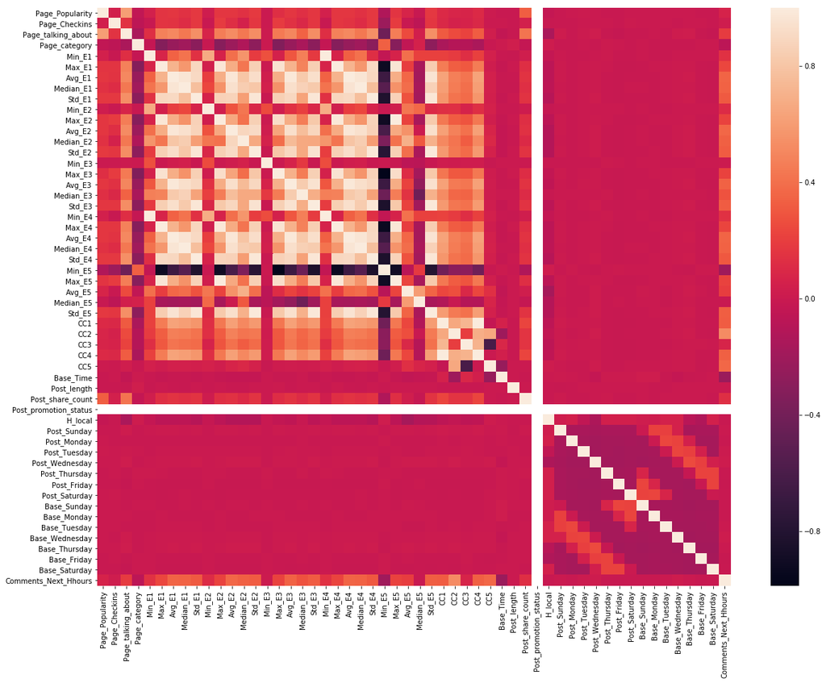

```python
plt.subplots(figsize=(20,15))
sns.heatmap(df.corr())
```

#### Based on exploratory data analysis and intuition, it seems that most important variable in predicting the comments in next H hours should be post features like- likes,shares,length of post. Intrinsic features like when the post was made(CC1,CC2.CC3,CC4,CC5) also seem relevant. These have been included in model to experiment, later a legitimate approach is used to determine true relevant features of target variable.

```python
colsSelected=['Page_Popularity','Page_Checkins','Page_talking_about','Base_Time','Post_length',
       'Post_share_count','Post_promotion_status','CC1','CC2','CC3','CC4','CC5','H_local']
```

```python
xTest_sub,xTrain_sub=xTest[colsSelected],xTrain[colsSelected]
xTrain_sub.head()
```

|  | Page_Popularity | Page_Checkins | Page_talking_about | Base_Time | Post_length | Post_share_count | Post_promotion_status | CC1 | CC2 | CC3 | CC4 | CC5 | H_local |
| --- | --- | --- | --- | --- | --- | --- | --- | --- | --- | --- | --- | --- | --- |
| 143059 | 1340759 | 33935 | 49392 | 15 | 53 | 55 | 0 | 46 | 46 | 0 | 46 | 46 | 24 |
| 84923 | 3280313 | 1 | 39324 | 67 | 367 | 1942 | 0 | 460 | 10 | 91 | 401 | -81 | 24 |
| 127752 | 274207 | 0 | 100435 | 14 | 47 | 25 | 0 | 161 | 161 | 0 | 161 | 161 | 24 |
| 52483 | 3159268 | 0 | 155474 | 22 | 318 | 14 | 0 | 14 | 14 | 0 | 14 | 14 | 24 |
| 52516 | 3159268 | 0 | 155474 | 15 | 102 | 16 | 0 | 5 | 5 | 0 | 5 | 5 | 12 |

```python
xTrain_sub.shape
```

```
(112987, 13)
```

```python
xTest_sub.shape
```

```
(48423, 13)
```

```python
xTrain_matrix=np.array(xTrain_sub)
xTest_matrix=np.array(xTest_sub)
yTrain_vector=np.array(yTrain)
yTest_vector=np.array(yTest)
yTrain_vector.shape
```

```
(112987,)
```

```python
yTest_vector.shape
```

```
(48423,)
```

```python
xTrain_matrix.shape
```

```
(112987, 13)
```

#### Plotting the frequency distribution of the selected variables to understand the spread of the data

```python
def feature_distribution(xTrain):
    plt.figure(figsize=(10,4))
    plt.grid(True)
    plt.xlim([-100,5000])
    plt.ylim([0,100])
    plt.subplot(2,2,1)
    myplot = plt.hist(xTrain[:,0],label = 'Page_Popularity')
    plt.xlabel('Column Value')
    plt.ylabel('Counts')
    myplot = plt.legend()
    plt.subplot(2,2,2)
    myplot = plt.hist(xTrain[:,1],label = 'Page_Checkins')
    plt.xlabel('Column Value')
    plt.ylabel('Counts')
    myplot = plt.legend()
    plt.subplot(2,2,3)
    myplot = plt.hist(xTrain[:,2],label = 'Page_talking_about')
    plt.xlabel('Column Value')
    plt.ylabel('Counts')
    myplot = plt.legend()
    plt.subplot(2,2,4)
    myplot = plt.hist(xTrain[:,4],label = 'Post_length')
    #plt.title('Histogram for columns 1,2,3,4')
    plt.xlabel('Column Value')
    plt.ylabel('Counts')
    myplot = plt.legend()
```

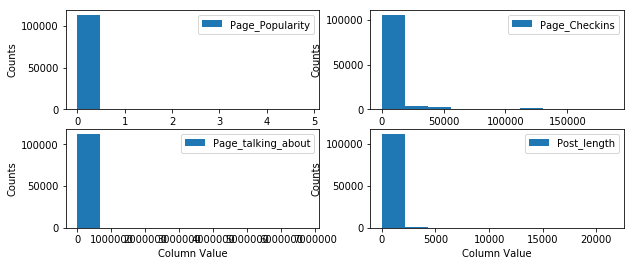

```python
feature_distribution(xTrain_matrix)
```